# Exercise 6 — Cluster Detection with SaTScan

BSTA 374 · 17.5 points · Due Friday, October 30, 2026, 11:59 pm

Author

Mamun Ur Rashid Pranta · Lehigh University

Published

October 28, 2026

## What this exercise is

Exercises 4 and 5 asked whether counties with similar SMRs sit next to each other. The **spatial scan statistic** asks a different question: *is there a group of neighbouring counties where more people died than expected?* You can answer this question using **SaTScan**, on the same data: 2020 COVID-19 deaths in Pennsylvania’s 67 counties.

Every SaTScan analysis rests on choices made before the scan runs. You make three of them here and see how each changes the answer:

1. the **probability model** (Part B);
2. the **maximum size of the scanning window** (Part C);
3. how to read the **Monte Carlo** $p$-value (Part D).

**Everything runs from this file.** R writes SaTScan’s input files and a parameter file, runs SaTScan in the background, and reads the results back. You do not need to open the SaTScan window. **All the R code is provided**; you do not need to write new code. Run the chunks one at a time with the green ▶ button, read the output, and type your answer under each question. One or two sentences per question is enough.

**ImportantBefore you start**

1. Install **SaTScan** (free) from satscan.org, version 10.3 or later; the download asks you to fill in a short form. Keep the default location: on Windows the installer puts it in `C:\Program Files\SaTScan`; on a Mac, drag **SaTScan** into **Applications**.
2. In the RStudio **Console**, run once: `install.packages("rsatscan")`.
3. Save this file as `LASTNAME_FI_Exercise6.qmd` and put `pa_covid_deaths_2020.csv` in a `data/` folder next to it, as in Exercise 5.
4. I strongly suggest that you look into the satscan [tutorial](https://www.satscan.org/cgi-bin/satscan/register.pl/SaTScan_Users_Guide.pdf?todo=process_userguide_download)

**ImportantSubmission**

Choose **either** option; both earn the same credit.

- **Option 1:** upload `LASTNAME_FI_Exercise6.qmd`, with your answers typed in, to Course Site. No rendering needed.
- **Option 2:** render the page, publish it to GitHub Pages as for Exercise 4, and submit the `.qmd` and the page URL.

**TipIf something does not run**

- Restart R (*Session → Restart R*) and run the chunks from the top, in order. Most errors come from a chunk skipped or run out of order.
- If the `find-satscan` chunk stops with *SaTScan not found*, locate `SaTScanBatch64.exe` (Windows) or `SaTScan.app` (Mac) on your computer and follow the instruction in that chunk.
- On a Mac, if SaTScan is found but does not run, open SaTScan once from **Applications**, close it, and try again.
- If it still fails, email me the exact error message — or answer the questions you can; partial answers earn partial credit.

### The five SaTScan runs at a glance

| Run | Scan for | Maximum window | Replications | Part |
| --- | --- | --- | --- | --- |
| `high50` | high rates | 50% of population | 999 | B |
| `high25` | high rates | 25% | 999 | C |
| `high15` | high rates | 15% | 999 | C |
| `high25_r99` | high rates | 25% | 99 | D |
| `low25` | low rates | 25% | 999 | E |

## Part A — Find SaTScan and prepare the input files (1.5 points)

This chunk repeats the first steps of Exercises 4 and 5: the join, the state rate and the expected deaths.

```r
library(sf)
library(dplyr)
library(readr)
library(ggplot2)
library(patchwork)
library(rsatscan)                   # runs SaTScan from R
library(tigris)
options(tigris_use_cache = TRUE)

covid <- read_csv("data/pa_covid_deaths_2020.csv", show_col_types = FALSE) |>
  mutate(GEOID = sprintf("%05d", as.integer(FIPS)))      # text key, as in Ex. 4
pa <- counties(state = "PA", cb = TRUE, year = 2020, progress_bar = FALSE)

pa_covid <- pa |>
  left_join(covid, by = "GEOID") |>
  st_transform(5070) |>
  arrange(GEOID)

r <- sum(pa_covid$deaths_2020) / sum(pa_covid$Population)   # state rate
pa_covid <- pa_covid |>
  mutate(E   = r * Population,                              # expected deaths
         SMR = deaths_2020 / E)
```

R needs to know where SaTScan’s **batch program** is: the part of SaTScan that runs without a window. The chunk looks in the places the installer uses.

```r
# if SaTScan is installed elsewhere, paste the full path to
# SaTScanBatch64.exe (Windows) or satscan (Mac) between the quotes
my_path <- ""

candidates <- c(my_path,
                "C:/Program Files/SaTScan/SaTScanBatch64.exe",      # Windows
                "C:/Program Files (x86)/SaTScan/SaTScanBatch.exe",  # Windows, 32-bit
                "/Applications/SaTScan.app/Contents/app/satscan",   # Mac
                "/opt/satscan/lib/app/satscan64")                   # Linux
ss_exe <- candidates[candidates != "" & file.exists(candidates)][1]
if (is.na(ss_exe)) stop("SaTScan not found: install it, or set my_path above")

ss_dir   <- dirname(ss_exe)                                 # its folder
ss_batch <- tools::file_path_sans_ext(basename(ss_exe))     # its name
ss_exe
```

```
[1] "C:/Program Files/SaTScan/SaTScanBatch64.exe"
```

SaTScan reads three plain text files linked by a **location ID**, here the county `GEOID`, exactly as in the lecture.

| File | Columns | Here |
| --- | --- | --- |
| Case file `.cas` | location ID, number of cases | GEOID, deaths in 2020 |
| Population file `.pop` | location ID, year, population | GEOID, 2020, population |
| Coordinates file `.geo` | location ID, latitude, longitude | GEOID, county centroid |

```r
dir.create("satscan", showWarnings = FALSE)                  # folder for SaTScan
ss_folder <- normalizePath("satscan", winslash = "/")        # its full path

# county centroids in latitude / longitude
ll <- pa_covid |>
  st_centroid() |>
  st_transform(4326) |>                         # SaTScan wants lat/long
  st_coordinates()

# one plain table with everything SaTScan needs
ss <- pa_covid |>
  st_drop_geometry() |>
  mutate(year = 2020,
         lat  = round(ll[, "Y"], 5),
         lon  = round(ll[, "X"], 5))

# three files, no header (rsatscan adds the extensions)
write.cas(select(ss, GEOID, deaths_2020),      ss_folder, "pa_covid")
write.pop(select(ss, GEOID, year, Population), ss_folder, "pa_covid")
write.geo(select(ss, GEOID, lat, lon),         ss_folder, "pa_covid")

# first three lines of each file
readLines("satscan/pa_covid.cas", n = 3)
```

```
[1] "42001 88"   "42003 1009" "42005 69"
```

```r
readLines("satscan/pa_covid.pop", n = 3)
```

```
[1] "42001 2020 103009"  "42003 2020 1216045" "42005 2020 64735"
```

```r
readLines("satscan/pa_covid.geo", n = 3)
```

```
[1] "42001 39.87147 -77.2179"  "42003 40.46868 -79.98121"
[3] "42005 40.81193 -79.46461"
```

```r
# totals written to the files
c(deaths = sum(ss$deaths_2020), population = sum(ss$Population))
```

```
    deaths population
     16030   12801989
```

**WarningTwo common mistakes**

- The coordinates file lists **latitude, then longitude**. Swapped, they put Pennsylvania in Antarctica, and SaTScan still runs.
- The location IDs must be **identical** in all three files. A county whose ID does not match is dropped without an error message.

**A1.** How many deaths and how many people did you write to the files?

Answer: I wrote 16,030 deaths and a population of 12,801,989 people to the files

**A2.** SaTScan places each county at a single point, its centroid, and a county enters a scanning circle when that point does. Think of a large rural county whose people live mostly in one town near its edge. Why might the centroid misplace that county’s deaths?

Answer: The county’s center may be far from the town where most people live and deaths occur. Putting all deaths at that center could make the scanning circle include or miss them because it uses the wrong location.

## Part B — Choose the model and run the scan (4.5 points)

### Which probability model?

SaTScan offers several probability models. The model depends on the **data you have**, not on the result you hope for.

| Model | Data needed | Typical use |
| --- | --- | --- |
| Poisson | case counts and population at risk | rates by area |
| Bernoulli | cases and controls (0/1 for each person) | case–control studies |
| Space–time permutation | case counts with dates, no population | rapid outbreak detection |
| Normal | a continuous measurement | e.g. birth weight, exposure levels |

**B1.** For each study, name the model you would choose and say in a few words why. Copy the table and fill it in.

Answer:

| Study | Model | Why |
| --- | --- | --- |
| (a) COVID-19 deaths by county, with each county’s population (this exercise) | Poisson | We have death counts and the population at risk for each county. |
| (b) Children born with a heart defect, and a random sample of children born without one, each with a home address | Bernoulli | We have individual cases and controls– children with and without a heart defect |
| (c) Daily emergency-room visits for diarrhoea by ZIP code, with no reliable population for the ZIP codes | Space-time permutation | We have the locations and dates of visits but no reliable population figures. |
| (d) Blood lead level (µg/dL) of every child tested in each census tract | Normal | Blood lead level is a continuous measurement |

**B2.** We scan **deaths**, yet the Poisson model also needs a **population** file. What does SaTScan use the population for, and what is the null hypothesis the scan tests?

Answer: SaTScan uses each county’s population to work out how many deaths to expect at the statewide mortality rate. The null hypothesis is that the risk of death is the same across Pennsylvania, and differences in death counts are due to population size and chance.

### The settings

In class you chose the settings on the tabs of the SaTScan window. Here the same settings go into a **parameter file** (`.prm`) that SaTScan reads. The function below writes that file with `ss.options()` and then runs SaTScan.

| Setting in the code | Tab in the SaTScan window | Value here |
| --- | --- | --- |
| `CaseFile`, `PopulationFile`, `CoordinatesFile` | Input | the three files from Part A |
| `CoordinatesType = 1` | Input | latitude / longitude |
| `PrecisionCaseTimes = 0` | Input | time precision: none |
| `AnalysisType = 1` | Analysis | purely spatial |
| `ModelType = 0` | Analysis | discrete Poisson |
| `ScanAreas` | Analysis | 1 = high rates, 2 = low rates |
| `MaxSpatialSizeInPopulationAtRisk` | Analysis → Advanced → Spatial Window | maximum window, % of population |
| `MonteCarloReps` | Analysis → Advanced → Inference | number of replications |
| `PValueReportType = 1` | Analysis → Advanced → Inference | standard Monte Carlo $p$-value |

Only three settings change between runs, so they are the function’s arguments: what to scan for, the maximum window and the number of replications.

```r
run_satscan <- function(name, scan_for = "high", max_window = 50, reps = 999) {
  invisible(ss.options(reset = TRUE))                    # start from defaults
  ss.options(list(
    CaseFile           = "pa_covid.cas",                 # input files
    PopulationFile     = "pa_covid.pop",
    CoordinatesFile    = "pa_covid.geo",
    CoordinatesType    = 1,                              # latitude / longitude
    PrecisionCaseTimes = 0,                              # no dates
    StartDate          = "2020/1/1",
    EndDate            = "2020/12/31",
    AnalysisType       = 1,                              # purely spatial
    ModelType          = 0,                              # discrete Poisson
    ScanAreas          = if (scan_for == "high") 1 else 2,  # high or low rates
    MaxSpatialSizeInPopulationAtRisk = max_window,       # % of population
    SpatialWindowShapeType = 0,                          # circles
    MonteCarloReps     = reps,                           # random maps
    PValueReportType   = 1,                              # standard Monte Carlo
    SaveSimLLRsDBase   = "y",                            # keep their LLRs
    OutputGoogleMaps   = "n",                            # no extra output
    LaunchMapViewer    = "n",
    OutputShapefiles   = "n"))
  write.ss.prm(ss_folder, name)                          # parameter file
  res <- satscan(ss_folder, name, sslocation = ss_dir,
                 ssbatchfilename = ss_batch, cleanup = FALSE)   # run SaTScan
  if (!is.data.frame(res$col)) stop("SaTScan produced no clusters: check the files in Part A")
  res
}
```

**NoteWhy standard Monte Carlo?**

SaTScan’s default $p$-value replaces very small Monte Carlo $p$-values with an approximation (Gumbel) and can print values such as $10^{-17}$. We ask for the **standard Monte Carlo** $p$-value so that every $p$-value comes straight from the replications, and you can check it by hand in Part D.

### Run 1: `high50`

```r
high50 <- run_satscan("high50", scan_for = "high", max_window = 50, reps = 999)
```

SaTScan wrote `high50.prm` (the settings), `high50.txt` (the results, for people) and three `.dbf` files (the results, for software) in your `satscan` folder. If you like, open `high50.prm` in the SaTScan window: the same settings appear on the tabs you saw in class.

### Read the results

The top of `high50.txt` gives the SaTScan version, the analysis, and a *SUMMARY OF DATA* that reports what SaTScan read:

```r
txt   <- high50$main                                        # high50.txt, line by line
start <- grep("SUMMARY OF DATA", txt)
cat(txt[1:(start + 8)], sep = "\n")
```

```
                                 _____________________________

                                        SaTScan v10.3.3
                                 _____________________________


Program run on: Wed Oct 28 21:56:07 2026

Purely Spatial analysis
scanning for clusters with high rates
using the Discrete Poisson model.
_______________________________________________________________________________________________

SUMMARY OF DATA

Study period.......................: 2020/1/1 to 2020/12/31
Number of locations................: 67
Population, averaged over time.....: 12801989
Total number of cases..............: 16030
Annual cases / 100000..............: 125.0
_______________________________________________________________________________________________
```

Two helper functions turn the results into a table, with one row per cluster, and a map. You do not need to understand them to use them.

**Code for the two helper functions (optional)**

```r
# table: one row per cluster SaTScan reported
ss_table <- function(res) {
  col <- res$col                                            # clusters
  gis <- res$gis                                            # counties in them
  out <- NULL
  for (k in col$CLUSTER) {
    cl     <- col[col$CLUSTER == k, ]                       # cluster k
    inside <- pa_covid$GEOID %in% trimws(as.character(gis$LOC_ID[gis$CLUSTER == k]))
    row <- data.frame(
      cluster   = k,
      counties  = paste(sort(pa_covid$NAME[inside]), collapse = ", "),
      n         = sum(inside),                              # number of counties
      pop_pct   = round(100 * sum(pa_covid$Population[inside]) /
                          sum(pa_covid$Population), 1),     # % of state population
      radius_km = round(cl$RADIUS),
      observed  = cl$OBSERVED,
      expected  = round(cl$EXPECTED),
      O_E       = round(cl$ODE, 2),                         # inside vs state rate
      RR        = round(cl$REL_RISK, 2),                    # inside vs outside
      LLR       = round(cl$LLR, 2),
      p_value   = cl$P_VALUE)
    out <- rbind(out, row)                                  # add the row
  }
  out
}

# map: clusters with p < 0.05 in colour (dark = most likely), the rest grey
ss_map <- function(res, title, colours = c("#67000D", "#CB181D", "#FB6A4A", "#FCBBA1")) {
  tab <- ss_table(res)
  gis <- res$gis
  sig <- tab$cluster[tab$p_value < 0.05]                    # significant clusters
  pa_covid$cluster <- NA                                    # no cluster yet
  for (k in sig) {
    ids <- trimws(as.character(gis$LOC_ID[gis$CLUSTER == k]))
    pa_covid$cluster[pa_covid$GEOID %in% ids] <- k
  }
  ggplot() +
    geom_sf(data = pa_covid, fill = "grey92", colour = "white", linewidth = 0.15) +
    geom_sf(data = filter(pa_covid, !is.na(cluster)),
            aes(fill = factor(cluster)), colour = "white", linewidth = 0.15) +
    scale_fill_manual(values = colorRampPalette(colours)(length(sig)),
                      name = "Cluster") +                   # dark to light
    labs(title = title, subtitle = "Clusters with p < 0.05") +
    theme_void()
}
```

```r
tab50 <- ss_table(high50)
knitr::kable(tab50)                           # every cluster SaTScan reported
```

| cluster | counties | n | pop_pct | radius_km | observed | expected | O_E | RR | LLR | p_value |
| --- | --- | --- | --- | --- | --- | --- | --- | --- | --- | --- |
| 1 | Berks, Bradford, Bucks, Carbon, Columbia, Delaware, Lackawanna, Lehigh, Luzerne, Monroe, Montgomery, Montour, Northampton, Northumberland, Philadelphia, Pike, Schuylkill, Sullivan, Susquehanna, Wayne,… | 21 | 47.1 | 160 | 8717 | 7542 | 1.16 | 1.34 | 172.43 | 0.001 |
| 2 | Huntingdon, Juniata, Mifflin | 3 | 0.9 | 38 | 253 | 145 | 1.74 | 1.75 | 32.97 | 0.001 |
| 3 | Bedford, Blair, Cambria, Indiana | 4 | 3.0 | 58 | 642 | 481 | 1.34 | 1.35 | 25.26 | 0.001 |
| 4 | Beaver, Lawrence | 2 | 1.9 | 34 | 378 | 312 | 1.21 | 1.22 | 6.60 | 0.051 |

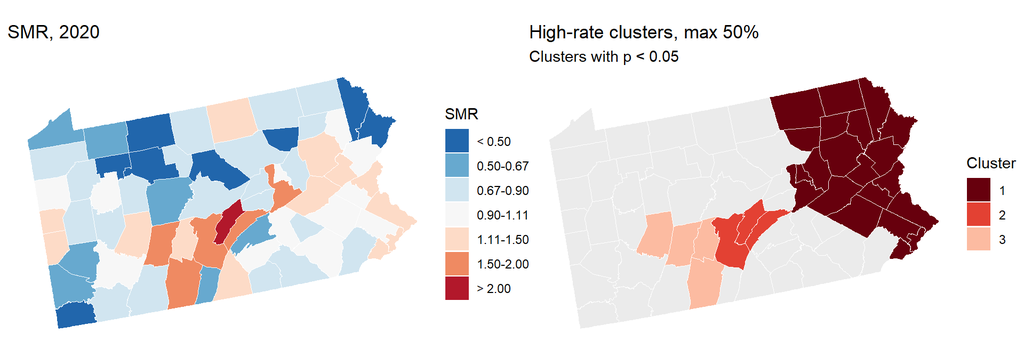

```r
# the SMR map, for comparison, with the classes of Exercise 4
pa_covid <- pa_covid |>
  mutate(smr_class = cut(SMR, breaks = c(0, 0.5, 2/3, 0.9, 1/0.9, 1.5, 2, Inf),
                         labels = c("< 0.50", "0.50-0.67", "0.67-0.90", "0.90-1.11",
                                    "1.11-1.50", "1.50-2.00", "> 2.00")))
p_smr <- ggplot(pa_covid) +
  geom_sf(aes(fill = smr_class), colour = "white", linewidth = 0.15) +
  scale_fill_brewer(palette = "RdBu", direction = -1, drop = FALSE, name = "SMR") +
  labs(title = "SMR, 2020") +
  theme_void()

p_smr + ss_map(high50, "High-rate clusters, max 50%")
```

| Column | Meaning |
| --- | --- |
| `observed`, `expected` | deaths inside the circle, and the number expected at the state rate |
| `O_E` | observed / expected: the rate inside compared with the **state** rate |
| `RR` | relative risk: the rate inside divided by the rate **outside** the circle |
| `LLR` | log-likelihood ratio: the strength of the evidence; the largest is the most likely cluster |
| `radius_km` | distance from the circle’s centre to its farthest county centroid |

**B3.** Compare the *SUMMARY OF DATA* printed above with your totals in A1. Did SaTScan read every county, every death and every person? Why is this check worth making before you read any cluster?

Answer: Yes. SaTScan read all 67 counties, 16,030 deaths, and 12,801,989 people,matching the totals in A1. This check helps make sure no records were lost or read incorrectly before we interpret the clusters

**B4.** Describe the **most likely cluster** (cluster 1): how many counties, what share of the state’s population, its observed/expected ratio and its relative risk. Look at the SMR map: is every county inside it above 1? Why is its RR larger than its O/E?

Answer:The most likely cluster includes 21 counties, mainly in eastern Pennsylvania, containing 47.1% of the state’s population. It recorded 8,717 deaths, compared with about 7,542 expected, giving an O/E of 1.16 and an RR of 1.34. Not every county inside has an SMR above 1, because the scan considers the group as a whole. RR is larger because it compares the cluster with the lower mortality rate outside it, while O/E compares it with the statewide rate.

**B5.** How many clusters did SaTScan report, and how many have $p < 0.05$? Why does SaTScan list clusters that are not significant, and why does our map colour only those with $p < 0.05$?

Answer: SaTScan reported four clusters, and three had p < 0.05. The fourth cluster,Beaver and Lawrence, had p = 0.051. SaTScan lists it as a possible cluster, but our map colors only those that meet the significance threshold

## Part C — The maximum window (4 points)

The 50% maximum is SaTScan’s default, not a rule. We run the scan twice more, changing **only** the maximum window.

```r
high25 <- run_satscan("high25", scan_for = "high", max_window = 25, reps = 999)
high15 <- run_satscan("high15", scan_for = "high", max_window = 15, reps = 999)

tab25 <- ss_table(high25)
tab15 <- ss_table(high15)

knitr::kable(tab25, caption = "Maximum 25%")
```

Maximum 25%

| cluster | counties | n | pop_pct | radius_km | observed | expected | O_E | RR | LLR | p_value |
| --- | --- | --- | --- | --- | --- | --- | --- | --- | --- | --- |
| 1 | Delaware, Montgomery, Philadelphia | 3 | 23.3 | 30 | 4548 | 3734 | 1.22 | 1.30 | 110.58 | 0.001 |
| 2 | Northumberland | 1 | 0.7 | 0 | 226 | 114 | 1.99 | 2.00 | 43.30 | 0.001 |
| 3 | Huntingdon, Juniata, Mifflin | 3 | 0.9 | 38 | 253 | 145 | 1.74 | 1.75 | 32.97 | 0.001 |
| 4 | Bedford, Blair, Cambria, Indiana | 4 | 3.0 | 58 | 642 | 481 | 1.34 | 1.35 | 25.26 | 0.001 |
| 5 | Berks, Bucks, Carbon, Columbia, Lackawanna, Lehigh, Luzerne, Monroe, Montour, Northampton, Pike, Schuylkill, Wyoming | 13 | 21.8 | 82 | 3827 | 3497 | 1.09 | 1.12 | 19.50 | 0.001 |
| 6 | Beaver, Lawrence | 2 | 1.9 | 34 | 378 | 312 | 1.21 | 1.22 | 6.60 | 0.046 |

```r
knitr::kable(tab15, caption = "Maximum 15%")
```

Maximum 15%

| cluster | counties | n | pop_pct | radius_km | observed | expected | O_E | RR | LLR | p_value |
| --- | --- | --- | --- | --- | --- | --- | --- | --- | --- | --- |
| 1 | Philadelphia | 1 | 12.4 | 0 | 2450 | 1983 | 1.24 | 1.28 | 58.84 | 0.001 |
| 2 | Northumberland | 1 | 0.7 | 0 | 226 | 114 | 1.99 | 2.00 | 43.30 | 0.001 |
| 3 | Delaware | 1 | 4.4 | 0 | 951 | 710 | 1.34 | 1.36 | 38.96 | 0.001 |
| 4 | Huntingdon, Juniata, Mifflin | 3 | 0.9 | 38 | 253 | 145 | 1.74 | 1.75 | 32.97 | 0.001 |
| 5 | Bedford, Blair, Cambria, Indiana | 4 | 3.0 | 58 | 642 | 481 | 1.34 | 1.35 | 25.26 | 0.001 |
| 6 | Carbon, Lehigh, Luzerne, Monroe, Northampton, Schuylkill | 6 | 10.7 | 49 | 1932 | 1713 | 1.13 | 1.15 | 15.16 | 0.001 |
| 7 | Bucks, Montgomery | 2 | 11.4 | 26 | 2051 | 1827 | 1.12 | 1.14 | 14.96 | 0.001 |
| 8 | Beaver, Lawrence | 2 | 1.9 | 34 | 378 | 312 | 1.21 | 1.22 | 6.60 | 0.040 |
| 9 | Lancaster | 1 | 4.3 | 0 | 731 | 683 | 1.07 | 1.07 | 1.70 | 0.982 |

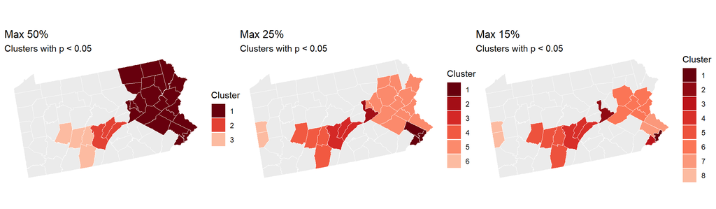

```r
# the three runs side by side
ss_map(high50, "Max 50%") + ss_map(high25, "Max 25%") + ss_map(high15, "Max 15%")
```

```r
# one line per run, for the most likely cluster
runs <- list("50%" = tab50, "25%" = tab25, "15%" = tab15)
compare <- NULL
for (w in names(runs)) {
  tab <- runs[[w]]
  compare <- rbind(compare, data.frame(
    max_window   = w,
    significant  = sum(tab$p_value < 0.05),     # clusters with p < 0.05
    mlc_counties = tab$n[1],                    # most likely cluster
    mlc_pop_pct  = tab$pop_pct[1],
    mlc_RR       = tab$RR[1],
    mlc_LLR      = tab$LLR[1]))
}
knitr::kable(compare)
```

| max_window | significant | mlc_counties | mlc_pop_pct | mlc_RR | mlc_LLR |
| --- | --- | --- | --- | --- | --- |
| 50% | 3 | 21 | 47.1 | 1.34 | 172.43 |
| 25% | 6 | 3 | 23.3 | 1.30 | 110.58 |
| 15% | 8 | 1 | 12.4 | 1.28 | 58.84 |

**C1.** How does the most likely cluster change from the 50% to the 25% to the 15% window? Name its counties in the 15% run.

Answer:With the 50% window, the most likely cluster includes 21 counties and 47.1% of the state’s population. At 25%, it becomes Delaware, Montgomery, and Philadelphia, covering 23.3%. At 15%, it includes only Philadelphia, covering 12.4%, so the smaller windows identify more local areas.

**C2.** Which clusters appear in all three runs, with the same counties? Why does a cluster that survives a change of window deserve more confidence than one that does not?

Answer:Huntingdon–Juniata–Mifflin, Bedford–Blair-Cambria–Indiana, and Beaver–Lawrence appear with the same counties in all three runs. This makes their boundaries less dependent on the window choice, although Beaver–Lawrence is significant only in the 25% and 15% runs

**C3.** The window is defined by **population**, not by distance. Use the `radius_km` column to compare a cluster in the Philadelphia area with one in central or western Pennsylvania. Why are the circles so different in size? In the 15% run, could Philadelphia and Delaware counties ever fall in the same cluster? (Hint: `pop_pct`.)

Answer:In the 25% run, the Philadelphia-area cluster has a radius of 30 km and contains 23.3% of the population, while Bedford–Blair–Cambria–Indiana has a radius of 58 km but contains only 3%. People live closer together around Philadelphia, so a smaller circle includes more people. Philadelphia and Delaware cannot form one cluster in the 15% run because together they contain about 16.8% of the state’s population.

**C4.** Which maximum window would you use in a report to the Pennsylvania Department of Health, and why? There is no single right answer; give a reason.

Answer:I would use the 25% window because it identifies smaller regional clusters without splitting the Philadelphia area into separate counties as the 15% window does.I would also compare it with the other windows to show which findings stay consistent

## Part D — The Monte Carlo $p$-value (4.5 points)

SaTScan redistributes the observed deaths at random among the counties, in proportion to their expected deaths, scans that random map with every circle, and keeps the **largest** LLR. It repeats this 999 times, and our settings asked it to save those 999 values (`high50.llr.dbf`). In the histogram, the dashed line marks their 95th percentile: the LLR a cluster needs for $p < 0.05$.

```r
sims  <- high50$llr$LLR                    # largest LLR of each random map
col50 <- high50$col                        # the clusters, unrounded
length(sims)
```

```
[1] 999
```

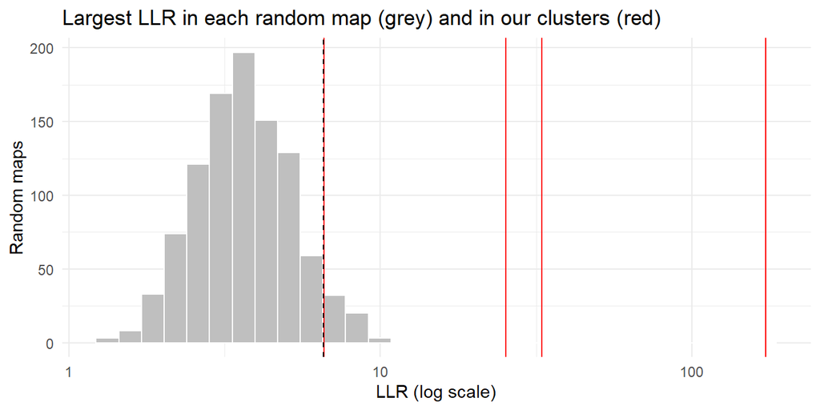

```r
ggplot(data.frame(LLR = sims), aes(x = LLR)) +
  geom_histogram(bins = 30, fill = "grey75", colour = "white") +
  geom_vline(xintercept = col50$LLR, colour = "red") +                  # our clusters
  geom_vline(xintercept = quantile(sims, 0.95), linetype = "dashed") +  # p = 0.05
  scale_x_log10() +
  labs(title = "Largest LLR in each random map (grey) and in our clusters (red)",
       x = "LLR (log scale)", y = "Random maps") +
  theme_minimal()
```

```r
# the p-value by hand, for each cluster
p_hand <- numeric(nrow(col50))
for (k in 1:nrow(col50)) {
  beat      <- sum(sims >= col50$LLR[k])            # random maps at least as high
  p_hand[k] <- (beat + 1) / (length(sims) + 1)
}
knitr::kable(data.frame(cluster   = col50$CLUSTER,
                        LLR       = round(col50$LLR, 2),
                        p_satscan = col50$P_VALUE,
                        p_by_hand = p_hand))
```

| cluster | LLR | p_satscan | p_by_hand |
| --- | --- | --- | --- |
| 1 | 172.43 | 0.001 | 0.001 |
| 2 | 32.97 | 0.001 | 0.001 |
| 3 | 25.26 | 0.001 | 0.001 |
| 4 | 6.60 | 0.051 | 0.051 |

**D1.** In your own words, what does one grey value in the histogram represent? Why is it the **largest** LLR of each random map that is kept, rather than the LLR of one circle?

Answer:Each grey value shows the strongest cluster found in one random map. I keep the strongest one because SaTScan searches many circles, and even a random map may contain something that looks like a cluster.

**D2.** Do your hand-computed $p$-values match SaTScan’s? Explain the formula in words. What is the smallest $p$-value 999 replications can give?

Answer:Yes, all four hand-calculated p-values match SaTScan’s: 0.001 for clusters 1–3 and 0.051 for cluster 4. For each cluster, I count how many simulated maps had a strongest cluster at least as strong as that cluster, add 1, and divide by 1,000. With 999 simulations, the smallest possible p-value is 0.001.

Now the same scan as `high25`, but with only **99** replications.

```r
high25_r99 <- run_satscan("high25_r99", scan_for = "high", max_window = 25, reps = 99)
tab25_99   <- ss_table(high25_r99)

# same clusters, two numbers of replications
left_join(select(tab25,    cluster, counties, LLR, p_999 = p_value),
          select(tab25_99, counties, p_99 = p_value),
          by = "counties") |>
  knitr::kable()
```

| cluster | counties | LLR | p_999 | p_99 |
| --- | --- | --- | --- | --- |
| 1 | Delaware, Montgomery, Philadelphia | 110.58 | 0.001 | 0.01 |
| 2 | Northumberland | 43.30 | 0.001 | 0.01 |
| 3 | Huntingdon, Juniata, Mifflin | 32.97 | 0.001 | 0.01 |
| 4 | Bedford, Blair, Cambria, Indiana | 25.26 | 0.001 | 0.01 |
| 5 | Berks, Bucks, Carbon, Columbia, Lackawanna, Lehigh, Luzerne, Monroe, Montour, Northampton, Pike, Schuylkill, Wyoming | 19.50 | 0.001 | 0.01 |
| 6 | Beaver, Lawrence | 6.60 | 0.046 | 0.07 |

**D3.** The clusters and their LLRs are the same in both runs; only the $p$-values change. What is the smallest $p$-value with 99 replications? Compare the $p$-values of the most likely cluster and of the weakest cluster in the two runs. Why do analysts use 999 or 9,999 replications rather than 99?

Answer:With 99 simulations, the smallest possible p-value is 0.01. The most likely cluster has a p-value of 0.01 with 99 simulations and 0.001 with 999. The weakest cluster, Beaver–Lawrence, has a p-value of 0.07 with 99 simulations and 0.046 with 999, so it falls below the 0.05 cutoff only in the second run. Analysts use 999 or 9,999 simulations to get more precise and stable p-values, especially near that cutoff.

**D4.** SaTScan looked at thousands of circles, yet we apply no multiple-testing correction. Local Moran’s I, by contrast, runs one test per county and needs one. Why is the scan’s $p$-value already protected against having searched so many circles?

Answer: SaTScan searches all the circles in every random map and keeps the strongest result. This already accounts for finding something unusual just because many circles were searched, so a separate correction for that search is not needed.

**D5.** A classmate writes: “The most likely cluster has $p = 0.001$, so there is a 99.9% chance that it is a real cluster.” Is this right? Rewrite the sentence so that it is correct.

Answer:No. A correct statement is: “If death risk were the same across the state, finding a cluster this strong or stronger would be very unlikely, with a Monte Carlo p-value of 0.001.” This does not tell us the probability that the cluster is real.

## Part E — Scanning for low rates (2 points)

The scan can also look for areas with **fewer** deaths than expected. One more run, with the 25% window and 999 replications.

```r
low25 <- run_satscan("low25", scan_for = "low", max_window = 25, reps = 999)
knitr::kable(ss_table(low25))
```

| cluster | counties | n | pop_pct | radius_km | observed | expected | O_E | RR | LLR | p_value |
| --- | --- | --- | --- | --- | --- | --- | --- | --- | --- | --- |
| 1 | Allegheny, Fayette, Greene, Washington | 4 | 12.4 | 71 | 1268 | 1989 | 0.64 | 0.61 | 168.33 | 0.001 |
| 2 | Cameron, Centre, Clarion, Clearfield, Clinton, Crawford, Elk, Erie, Forest, Jefferson, McKean, Potter, Tioga, Venango, Warren | 15 | 7.4 | 128 | 795 | 1184 | 0.67 | 0.65 | 77.45 | 0.001 |
| 3 | Adams, York | 2 | 4.3 | 42 | 507 | 691 | 0.73 | 0.72 | 28.19 | 0.001 |
| 4 | Wayne | 1 | 0.4 | 0 | 18 | 64 | 0.28 | 0.28 | 23.46 | 0.001 |
| 5 | Dauphin, Lebanon, Perry, Snyder | 4 | 4.0 | 46 | 546 | 635 | 0.86 | 0.86 | 6.74 | 0.046 |
| 6 | Bradford, Columbia, Lycoming, Sullivan, Wyoming | 5 | 2.1 | 47 | 280 | 340 | 0.82 | 0.82 | 5.73 | 0.108 |
| 7 | Chester | 1 | 4.1 | 0 | 587 | 657 | 0.89 | 0.89 | 4.07 | 0.370 |

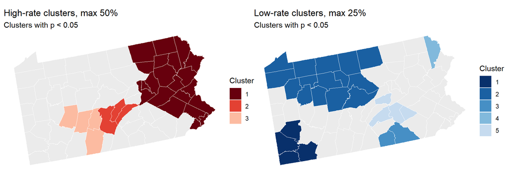

```r
ss_map(high50, "High-rate clusters, max 50%") +
  ss_map(low25, "Low-rate clusters, max 25%",
         colours = c("#08306B", "#2171B5", "#6BAED6", "#C6DBEF"))
```

```r
# counties in the 50% most likely high-rate cluster that also sit in a
# significant low-rate cluster
in_mlc <- trimws(as.character(high50$gis$LOC_ID[high50$gis$CLUSTER == 1]))
in_low <- trimws(as.character(low25$gis$LOC_ID[low25$gis$P_VALUE < 0.05]))

pa_covid |>
  st_drop_geometry() |>
  filter(GEOID %in% intersect(in_mlc, in_low)) |>
  select(NAME, deaths_2020, E, SMR)
```

```
   NAME deaths_2020        E       SMR
1 Wayne          18 64.31163 0.2798872
```

**E1.** Where is the most likely **low-rate** cluster? Our expected deaths use one statewide rate, with no adjustment for age. Give one reason other than “less COVID-19” why a county or group of counties could have fewer deaths than expected.

Answer: The most likely low-rate cluster is in southwestern Pennsylvania. One possible reason is a younger population: younger people are less likely to die from COVID-19, and these expected counts do not account for age.

**E2.** Does any county belong both to the most likely high-rate cluster at 50% and to a significant low-rate cluster? What does that tell you about how to read the **outline** of a large cluster?

Answer:Yes. Wayne County belongs to both groups, with 18 deaths compared with about 64 expected. This shows that a large high-rate cluster can include counties with low rates the outline describes the group’s overall pattern, not every county inside it

## Part F — Reproducibility and AI use (1 point)

Each run left its parameter file (`.prm`) in your `satscan` folder, and SaTScan repeats every setting in a *PARAMETER SETTINGS* section at the end of each results file. The main ones for `high50`:

```r
keep <- grep(paste("Type of Analysis", "Probability Model", "Scan For Areas With",
                   "Maximum Spatial Cluster Size", "Window Shape", "P-Value Reporting",
                   "Number of Replications", "Criteria for Reporting", sep = "|"), txt)
cat(trimws(txt[keep]), sep = "\n")
```

```
Type of Analysis    : Purely Spatial
Probability Model   : Discrete Poisson
Scan For Areas With : High Rates
Maximum Spatial Cluster Size : 50 percent of population at risk
Window Shape                 : Circular
P-Value Reporting                  : Standard Monte Carlo
Number of Replications             : 999
Criteria for Reporting Secondary Clusters : No Geographical Overlap
```

**F1.** Name three settings that someone would need to reproduce your most likely cluster exactly. Why is a script that writes these settings more reliable than a description of what you clicked in the SaTScan window?

Answer: Three important settings are the Discrete Poisson model, a circular scanning window, and a maximum cluster size of 50% of the population. These control how expected deaths are calculated and which areas can form a cluster. Keeping the settings in a script makes the analysis easier to repeat because it uses the same choices each time, without relying on someone remembering which buttons they clicked.

**F2.** End your document with one sentence on whether and how you used AI tools.

Answer: I used ChatGPT to help me understand troubleshoot errors, and review my interpretations and wording.

## Points

| Part | What earns the points | Points |
| --- | --- | --- |
| A | Totals reported; centroid limitation explained | 1.5 |
| B | Models matched to studies; role of population and null hypothesis; data check; most likely cluster read (O/E vs RR); reported vs significant clusters | 4.5 |
| C | Change in the most likely cluster; stable clusters; population-based window and radius; window choice justified | 4 |
| D | Random-map maximum explained; $p$ by hand and its minimum; 99 vs 999 replications; built-in multiple-testing protection; correct reading of $p$ | 4.5 |
| E | Low-rate cluster located and an alternative explanation; overlap with the 50% cluster interpreted | 2 |
| F | Settings needed to reproduce the run; AI use note | 1 |
|  | **Total** | **17.5** |

Clear, simple sentences are what earn the points; length does not.